# Week 11

```python
import numpy as np
import matplotlib.pyplot as plt
```

*Project 3 comments*:

- example: "The graph above shows a really interesting behavior" - **What is the behavior???**
- Careful to the terminology : "The graph displays an exponential decay" - **You need to verify the exponential behavior**
- Code repetition

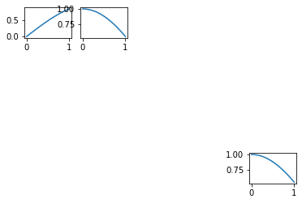

```python
x=np.linspace(0,1,100)
y=np.sin(x)
w=np.cos(x)

plt.subplot(5,5,1)
plt.plot(x,y)
plt.subplot(5,5,2)
plt.plot(x,w)

plt.subplot(5,5,25)
plt.plot(x,w)

plt.show()
```

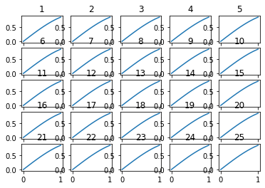

```python
for k in range(1,26):
    plt.subplot(5,5,k)
    plt.plot(x,y)
    plt.title(f'{k}')
```

```python
def f():
    for k in range(2):
        print(k)
```

```python
f()
```

```
0
1
```

```python
def f5():
    for k in range(5):
        print(k)
```

```python
f5()
```

```
0
1
2
3
4
```

```python
def fdef(n=2):
    for k in range(n):
        print(k)
```

```python
fdef(3)
```

```
0
1
2
```

```python
fdef()
```

```
0
1
```

```python
def f(xlist,ylist):
    m=len(xlist)
    n=len(ylist)
    k=0
    for k in range(m*n):
        plt.subplot(m,n,k+1)
        k+=1
```

```python
x=np.zeros((20,20))
x[0-1:0+2,0-1:0+2]
```

```
array([], shape=(0, 0), dtype=float64)
```

```python
Plan:
    let's switch on discord until 1pm
    room 1-9 group work
    room 10 alone work
```

```
  File "<ipython-input-29-ed2d1d30d795>", line 1
    Plan:
         ^
SyntaxError: invalid syntax
```

## File operations

`open()` opens a file (or it creates it), `write()` can be used to write in the file, `close()` is used to close the file

```python
f=open('grocery.txt','w') # open the file in writing mode
f.write('bread\n') # \n is a special character (newline)
f.write('bananas\n')
f.write('doritos\n')
f.write('takis\n')
f.write('eggs')
f.close()
```

```python
f=open('grocery.txt','a') # open the file in append mode (to add something to file)
```

```python
f.write('\n pizza')
f.close()
```

`read()` to read the file

```python
f=open('grocery.txt','r') # reading mode
```

```python
a=f.read()
print(a)
```

```
bread
bananas
doritos
takis
eggs
 pizza
```

```python
b=f.read()
print(b)
```

```python
f.tell() # the reading cursor is stuck at the end of the file
```

```
44
```

To read the file again we need to reset the cursor at the beginning (`seek()`)

```python
f.seek(0) # back at the beginning
f.tell()
```

```
0
```

```python
c=f.read()
print(c)
```

```
bread
bananas
doritos
takis
eggs
 pizza
```

```python
f.seek(0)
d=f.read(10) # will read the first 10 characters
print(d)
```

```
bread
bana
```

Other reading functions

```python
f.seek(0)
e=f.readlines() # reads the whole file and returns a list of lines
print(e)
```

```
['bread\n', 'bananas\n', 'doritos\n', 'takis\n', 'eggs\n', ' pizza']
```

```python
f.seek(0)
for line in f:
    print(line)
```

```
bread

bananas

doritos

takis

eggs

 pizza
```

```python
f.seek(0)
for k in range(5):
    print(f.readline())
```

```
bread

bananas

doritos

takis

eggs
```

```python
f.close()
```

## Sample quiz 8

```python
import matplotlib.pyplot as plt
import numpy as np
imga=np.random.rand(5,4,3)
```

Q3: write the code that makes a copy of `imga` (call the copy `imgb` ), and changes to black all the pixels where the red component of the image is greater than 0.5. Use boolean indexes.

```python
imgb=imga.copy()
```

```python
k=imgb[:,:,0]>0.5 # red above 0.5
```

```python
imgb[k] = 0
```

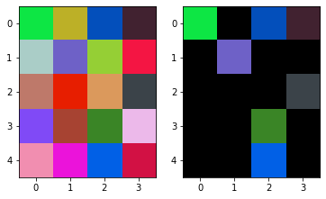

```python
plt.subplot(121)
plt.imshow(imga)
plt.subplot(122)
plt.imshow(imgb)
plt.show()
```

Q4: Write the code that makes a copy of `imga` (call the copy `imgc`), and changes to 1 the blue component of all the pixels where the green component of the image is between 0.1 and 0.7. Use boolean indexes.

```python
imgc=imga.copy()
greenzone1=imgc[:,:,1]<.7 # boolean array
greenzone2=imgc[:,:,1]>.1 # boolean array
cond = greenzone1 & greenzone2
print(cond)
```

```
[[False  True  True  True]
 [False  True False False]
 [ True  True  True  True]
 [ True  True  True False]
 [ True False  True False]]
```

```python
cond.shape
```

```
(5, 4)
```

```python
imgc[cond,2]=1
```

[figure not shown]

```python
plt.subplot(121)
plt.imshow(imga)
plt.subplot(122)
plt.imshow(imgc)
plt.show()
```

Q2: Write the code that creates a 3x4 array `a` with numbers from 0 to 11. Use boolean indexes to set all of the entries of `a`, that are less than 2 or greater than 8, equal to 0.

```python
a=np.arange(12).reshape(3,4)
print(a)
```

```
[[ 0  1  2  3]
 [ 4  5  6  7]
 [ 8  9 10 11]]
```

```python
c1=a<2 # entries of a that are less than 2
c2=a>8
c=c1|c2

a[c]=0
print(a)
```

```
[[0 0 2 3]
 [4 5 6 7]
 [8 0 0 0]]
```

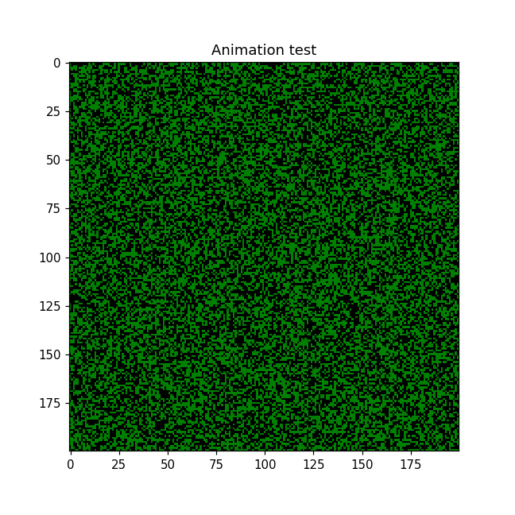

```python
%matplotlib notebook

import numpy as np
import matplotlib.pyplot as plt
from matplotlib.animation import FuncAnimation
from matplotlib import colors

x = np.zeros((200,200), dtype = int)

fig = plt.figure(figsize = (6,6))
ax = plt.subplot(111)
plt.title("Animation test")
cmap = colors.ListedColormap(['palegreen', 'green', 'black', 'orange'])
im = ax.imshow(x, cmap = cmap, vmin = -1, vmax = 2)

def animate(i):
    global x

    x=np.random.random(x.shape)
    im.set_data(x)
    return im


anim = FuncAnimation(fig=fig, func=animate,  interval=100, blit=True, repeat=False)
plt.show()
```

```python
%matplotlib inline
```

## Requests

```python
import requests # webpage communication
```

```python
ubm=requests.get('http://www.math.buffalo.edu')
```

```python
ubm # response euql to 200, means it worked
```

```
<Response [200]>
```

```python
dir(ubm)
```

[output not shown]

```python
ubm.status_code
```

```
200
```

```python
nyt=requests.get('http://www.nytimes.com/pippo')
nyt.status_code
```

```
404
```

```python
print(ubm.headers)
```

```
{'Date': 'Wed, 11 Nov 2020 17:09:11 GMT', 'Server': 'Apache/2.4.6 () Communique/4.3.3 OpenSSL/1.0.2k-fips', 'Last-Modified': 'Wed, 11 Nov 2020 17:09:02 GMT', 'ETag': '"2027c-5b3d7da229f5d-gzip"', 'Accept-Ranges': 'bytes', 'Vary': 'Accept-Encoding,User-Agent', 'Content-Encoding': 'gzip', 'Cache-Contr…
```

```python
print(ubm.text) # converts to a string the content of the page
```

[output not shown]

[output cut: 154 more lines]

[output not shown]

```python
tartan=requests.get('https://scassani.github.io/MTH337-F20/_images/Shapiro.png')
```

```python
tartan
```

```
<Response [200]>
```

```python
f=open('tartan.png','wb')
f.write(tartan.content)
f.close()
```

```python
book=requests.get('https://www.gutenberg.org/files/19513/19513.txt')
```

```python
verne=book.text # changing the content to string
```

```python
print(verne)
```

```
ï»¿The Project Gutenberg EBook A Journey to the Center of the Earth by
Jules Verne



This eBook is for the use of anyone anywhere at no cost and with almost no
restrictions whatsoever. You may copy it, give it away or re-use it under
the terms of the Project Gutenberg License included with this eBook or
online at http://www.gutenberg.org/license



Title: A Journey to the Center of the Earth

Subtitle: Reading by Vinny Bove, Mark Bradford, Hugh McGuire, Kristin Luoma,
          Mur Lafferty, Paul S. Jenkins, Alex Foster, Kristen McQuillin,
          Michael Crowl, Brad Bush, Lana Taylor, and Kara Shallenberg

Author: Jules Verne

Release Date: October 2006 [Ebook #19513]

Language: English



***START OF THE PROJECT GUTENBERG EBOOK A JOURNEY TO THE CENTER OF THE EARTH***



This audio reading of A Journey to the Center of the Earth is read by

Vinny Bove,
Mark Bradford,
Hugh McGuire,
Kristin Luoma,
Mur Lafferty,
Paul S. Jenkins,
Alex Foster,
Kristen McQuillin,
```

[output cut: 657 more lines]

```

    http://www.gutenberg.org


This Web site includes information about Project Gutenberg-tm, including how
to make donations to the Project Gutenberg Literary Archive Foundation,
how to help produce our new eBooks, and how to subscribe to our email
newsletter to hear about new eBooks.






***FINIS***
```

```python
len(verne)
```

```
25348
```

```python
n=len(verne)//2
chunkv=verne[n+3:n+100]
print(chunkv)
```

```
work, without prominently displaying
the sentence set forth in paragraph 1.E.1 with active links
```

## `replace`, `split`, `join`, `find`

```python
cv=chunkv.replace('a','&')
cv
```

```
'work, without prominently displ&ying\r\nthe sentence set forth in p&r&gr&ph 1.E.1 with &ctive links'
```

```python
cvol=chunkv.replace('\r\n',' ')
print(cvol)
```

```
work, without prominently displaying the sentence set forth in paragraph 1.E.1 with active links
```

Parenthesis on `\r`

```python
print('beginning\nEND')
```

```
beginning
END
```

```python
print('beginning\r\nEND')
```

```
beginning
END
```

```python
print('beginning\rEND')
```

```
END
```

`split`

```python
chunkv.split(' ') # splitting on the space character
```

```
['work,',
 'without',
 'prominently',
 'displaying\r\nthe',
 'sentence',
 'set',
 'forth',
 'in',
 'paragraph',
 '1.E.1',
 'with',
 'active',
 'links']
```

```python
chunkv.split() # splits on `'' ''`, `\r`, `\n`
```

```
['work,',
 'without',
 'prominently',
 'displaying',
 'the',
 'sentence',
 'set',
 'forth',
 'in',
 'paragraph',
 '1.E.1',
 'with',
 'active',
 'links']
```

```python
cs=chunkv.split('a')
print(cs)
```

```
['work, without prominently displ', 'ying\r\nthe sentence set forth in p', 'r', 'gr', 'ph 1.E.1 with ', 'ctive links']
```

`join` is used to join up a list of strings

```python
'a'.join(cs) # very particular syntax
```

```
'work, without prominently displaying\r\nthe sentence set forth in paragraph 1.E.1 with active links'
```

```python
cj='   '.join(cs)
print(cj)
```

```
work, without prominently displ   ying
the sentence set forth in p   r   gr   ph 1.E.1 with    ctive links
```